# M2 Visualisation d’informations sur R

ggplot2 - partie 3: Cartographie et extensions - Exercices corrigés

Arnaud MILET arnaud.milet@d-sidd.com

# 1 Exercice 1 (Carte simple)

1. À l’aide de la fonction WDI du package WDI, récupérer la série du PIB par tête (NY.GDP.PCAP.PP.KD, PPP, constant 2005 international $) pour tous les pays disponibles pour l’année 2010, et stocker ces données dans un tableau que l’on appellera gdp_capita ;

```r
library(WDI)
# NY.GDP.PCAP.PP.KD (GDP per capita, PPP (constant 2005 international $))
gdp_capita <-WDI(country = c("all"), indicator = c("NY.GDP.PCAP.PP.KD"), start = 2010, end = 2010)
```

2. Dans le tableau gdp_capita, modifier la valeur de la variable country pour l’observation de la Slovaquie, pour qu’elle vaille Slovakia au lieu de Slovak Republic ;

```r
library(dplyr)
library(magrittr)
gdp_capita <-gdp_capita %>%
  mutate(country = ifelse(country == "Slovak Republic", yes = "Slovakia", no = country))
```

3. Filtrer les observations du tableau gdp_capita pour ne conserver que les observations des pays membres de l’Union Européenne dont les noms sont contenus dans le vecteur membres_ue. Stocker le résultat dans un tableau que l’on nommera gdp_capita_eu ;

```r
membres_ue <-c("Austria", "Belgium", "Bulgaria", "Cyprus", "Croatia", "Czech Republic", "Denmark", "Estonia", "Finland", "France", "Germany", "Greece", "Hungary", "Ireland", "Italy", "Latvia", "Lithuania", "Luxembourg", "Malta", "Netherlands", "Poland", "Portugal", "Romania", "Slovakia", "Slovenia", "Spain", "Sweden", "United Kingdom")

gdp_capita_eu <-gdp_capita %>%
  filter(country %in% membres_ue)
```

4. Utiliser le package rworldmap pour récupérer les données nécessaires à la réalisation d’une carte du monde ;

```r
library(rworldmap)

world_map <- getMap()
world_df <- fortify(world_map)
```

5. Aﬃcher une carte du monde à l’aide des fonctions contenues dans le package ggplot2 ;

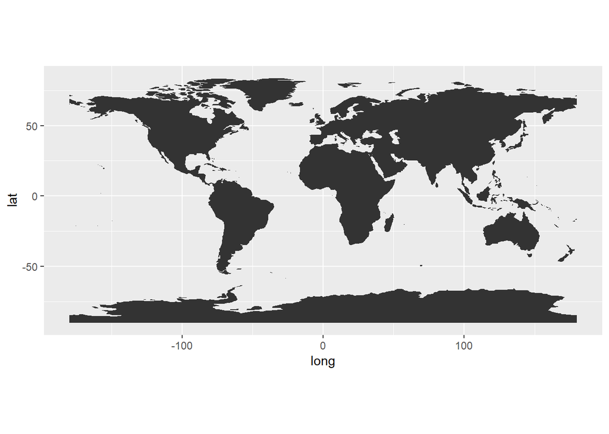

```r
ggplot(data = world_df, aes(x = long, y = lat, group = group)) +
  geom_polygon() +
  coord_quickmap()
```

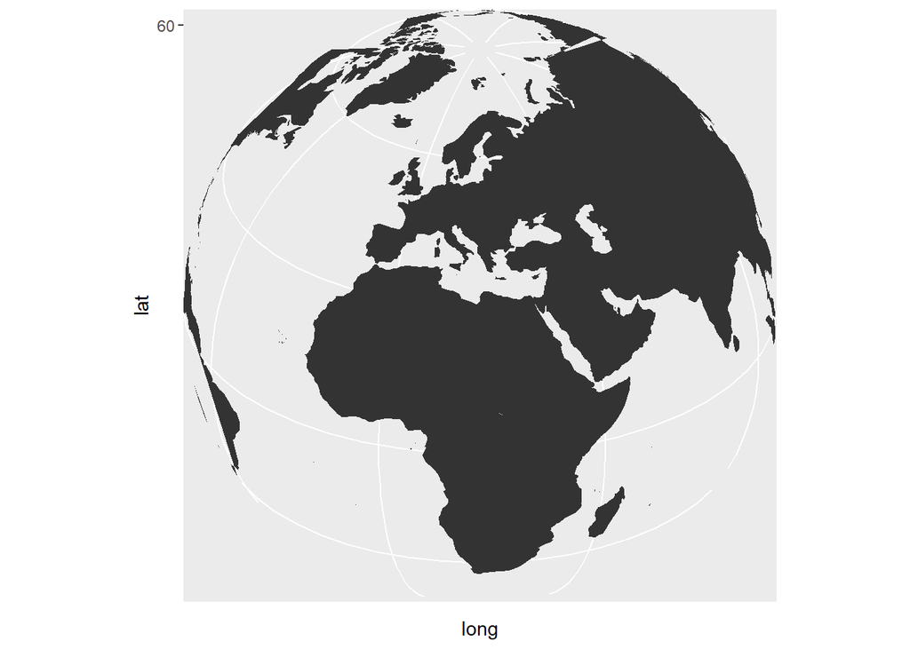

```r
ggplot(data = world_df, aes(x = long, y= lat, group=group)) +
  geom_polygon() +
  scale_y_continuous(breaks = (-2:2) * 30) +
  scale_x_continuous(breaks = (-4:4) * 45) +
  coord_map("orthographic", orientation=c(30, 20, 0))
```

7. Joindre les informations contenues dans le tableau gdp_capita_eu au tableau contenant les données permettant la réalisation des cartes ;

```r
world_df_eu <-world_df %>%
  left_join(gdp_capita_eu, by = c("id" = "country"))
```